# はじめに

## 今回のお話

- R Markdownがやってること
  - 処理の手順
  - 各処理の役割
  - 出力形式とテンプレート
- Rmdテンプレート開発
  - 基本編
  - アレ編

## 免責事項

- マニアックです
  - 今回話す内容は(多分)ほぼドキュメント化されてない内容
  - こんな世界なんだと思ってくれれば結構です．
- 応用場面は以下の2つしか浮かびません
  - Rmd周りでトラブルが発生して，かつ自力でどうにかしたい
  - 自分で自由にテンプレートを開発したいぜ!!!
- 必要知識が多めです
  - R, Rmdの知識とhtmlの知識は必須
  - Pandocの仕組みとテンプレートについての理解

# R Markdownがやっていること

## R Markdownとは

- Rの環境上でドキュメントを生成する**システム**
- Rコードの実行とその出力を含めてドキュメント化
  - 分析に再現性のあるドキュメントを生成
  - 多様な出力に対応
  - インタラクティブなPlotにも対応 etc…
- 基本はMarkdownドキュメント
  - 冒頭にyamlフロントマター
  - Rチャンクでコードを埋め込む
- 導入については以下を参照
  - [R Markdown入門 - Kazutan.R](https://kazutan.github.io/kazutanR/Rmd_intro.html)

## R Markdownの仕組み(基本)

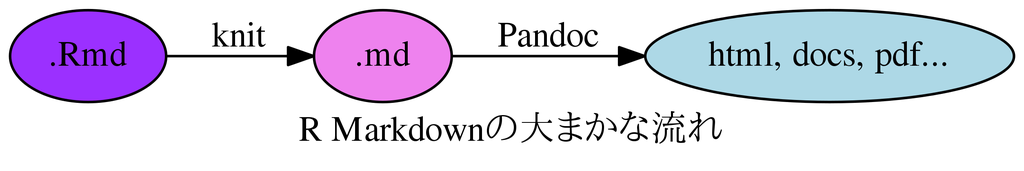

## これで済むはずがない

- ユーザーとして利用していくならこの図でOKだけど…
  - あれだけ多様なことをこなしている
  - どうやって細かい設定を反映させてるの?
  - そもそも，中身どうなってんの?

というわけで，もうちょっと覗き込みます

## R Markdownの処理フロー

renderは，だいたいこういう処理をしています:

1. 前処理
2. pre-knit処理
3. **knit**
4. post-knit処理
5. 中間処理
6. pre-processor
7. **pandoc**
8. post-processor
9. 後処理

## 基本的な考え方

- **knit**と**pandoc**の前後にそれぞれ処理が入る
- エラーチェックとか後片付けとか引き渡しとかもある
- `output_format`を参照し，その度にすべき処理内容を持ってくる
  - `output_format`については後述

なお，runtime(shinyまわり)や細かいところについては省略します

# 各処理の役割

## 前処理

- 実行環境のチェックとセットアップ
  - pandoc使うなら，それが使えるか
  - 中間生成物(intermediates)のチェック・準備
  - 出力先のチェック・準備 etc…
- inputのチェックと前処理
  - knitが必要か(r, rmd, rmarkdownがあるか)
  - パスに問題のある記号があるかどううか
- .rファイルをspinするための準備
  - `knitr::spin()`で*.rファイルを処理
  - yamlを仕込んでRmdファイル生成
- ファイル読み込み
  - inputをreadLine
  - yamlフロントマターを読み込んでyaml_front_matter
    - `rmarkdown::yaml_front_matter`を利用
    - [Rmdファイルのyamlフロントマターの内容を取得 - Qiita](http://qiita.com/kazutan/items/12fdbb8c5b0eae07872d) を参照
- output_formatのチェック
  - renderの引数にoutput_formatが指定されてないならyamlから持ってくる
- 最終的な出力先の準備
  - output_dirやfile，およびパスの準備
- post-knitの準備
  - `output_format`にあるpost-knitを読み込んで準備

## pre-knit

- knitのoptionsとhooksを別途格納して設定されてたのをrestore
- knitのchunk optionsをセット
- knitのknit optionsをセット
- knitのrootディレクトリやfigure, cacheパスをセット
- ユーザー設定のknitのoptionsやhooksとmerge
- paramsまわりの設定(この機能は以下の記事を参照)
  - [Parameterized Reports](http://rmarkdown.rstudio.com/developer_parameterized_reports.html)
- yaml_front_matterの内容を**metadata**としてknitのenvへ格納
  - 以降，設定指示した内容はこちらを参照するようになる

## knit

`knitr::knit()`

## post-knit

- post-knitで準備していた内容を呼び出す
- knit_metaに格納されたwarningを引っ張ってきて提示
  - knit中のエラーはこのタイミングで出てくる

## 中間処理

- html dependenciesのチェック
  - html形式以外の出力形式で，html用のものを使ってないかチェック
  - もし使っていたら警告とともにstpo
- knitした生成物をpandoc用の別ファイルへ書き出し
  - このときにencodingをutf_8に変換してる

## pre_prossessor

- pre-processorを取得
  - `output_format`よりpre_processorをextra_argsへ取り出す
  - このextra_argsを，pandocのargsへ統合する
- bibtex関連の処理
  - 出力形式がpdf|texかをチェック(違ったら叱る)
  - OKならpandoc$argsに組み込む

## pandoc

- ここまで`output_format$pandoc`に統合してきた内容を利用してconvert
  - pandocに送る**呪文**をここで詠唱

## post-prossessor

- 出力されてきたファイルに対し，post_processorを実行
  - `output_format`に格納されているpost_processorを呼び出す
  - output_fileに対して処理
- 無事終われば，`output created`となる

## 後処理

- keep_mdの処理
  - pandocにコンバートする前のファイル(imput_file)を利用
  - md用にyaml部分を調整し，出力ファイルと同じ場所に書き出し

## ようするに，何やってんの?

1. 前処理
2. knitのための設定などを読み込む
3. 「knit!」と唱える
4. knitの後始末
5. pandocへのargsを準備
6. 「pandoc!」と唱える
7. pandoc後の処理

…です

## んで，ポイントは?

1. renderはいろいろなんかやってる
2. **pre_knit**, **post_knit**, **pre_processor**, **post_processor**という処理が(実は)ある
3. `output_format`を常に参照してる

この3つをおさえておけば(今日の話は)OKです

# 出力とテンプレート

## 処理をテンプレートに集約

- renderはたくさんの処理をこなしている
  - ほしいもの，やってほしいことが多様
- それにあわせて，前の内容を作り変える必要
  - knit周りの設定
  - pandocへ送る呪文の設定
  - pandoc後の後始末 etc…
- これを毎度設定して準備するのは大変
  - ある程度テンプレートで提供する必要あり

## output_format

- rmarkdownのコアとなるもの(と私はかんがえてます)
- renderで処理してほしい内容を集約
  - renderは各処理でその都度これを参照
- **このoutput_formatを自分のやりたいように作ることができればOK**

## outuput_formatの構造

主なものは以下の通りです:

- knitr, pandoc
  - knitrやpandocに与えるoptionsやargsなどのlist
- pre_knit, post_knit
  - knit前後に処理する内容をそれぞれ関数にまとめたもの
- pre_processor, post_processor
  - pandoc前後に処理する内容をそれぞれ関数にまとめたもの
- base_format
  - **ベースにするフォーマットの関数**
  - 具体的には`html_document`など
  - 参照しない時は`NULL`

## output_formatを構築するには

- 普通に考えれば，以下の手順
  - それぞれの内容を記述
  - それをlistにする
- それって面倒なのには変わりないのでは?
  - はい
  - なので，出力形式ごとでテンプレートを準備します

## 出力形式テンプレート

- 特定の出力形式向けのテンプレートを提供する関数
  - 設定項目を引数で受け取る
  - その内容に基づき，`output_format`を出力
- ユーザーが基本触れるのはこれらです
  - `html_document`
  - `pdf_document`
  - `revealjs::revealjs_presentation` etc…

## 具体例 html_document

### pre_knit

Rmdのソースコード埋め込み用処理の関数

```
source_code <- NULL
source_file <- NULL
pre_knit <- function(input, ...) {
  if (code_download) {
    source_file <<- basename(input)
    source_code <<- paste0(
      '<div id="rmd-source-code">',
      base64enc::base64encode(input),
      '</div>')
  }
}
```

### post_knit

- ナビゲーションバー(navbar)を設置する処理
  - 本来ならpre_processorに組み込みたかった
  - でも名前がぶつかるなどの都合でこっちに入れたみたい

```r
post_knit <- function(metadata, input_file, runtime, encoding, ...) {
  # extra args
  args <- c()
  # navbar (requires theme)
  if (!is.null(theme)) {
    # add navbar to includes if necessary
    navbar <- file.path(normalize_path(dirname(input_file)), "_navbar.html")
    # if there is no _navbar.html look for a _navbar.yml
    if (!file.exists(navbar)) {
      navbar_yaml <- file.path(dirname(navbar), "_navbar.yml")
      if (file.exists(navbar_yaml))
        navbar <- navbar_html_from_yaml(navbar_yaml)
      # if there is no _navbar.yml then look in site config (if we have it)
      config <- site_config(input_file, encoding)
      if (!is.null(config) && !is.null(config$navbar))
        navbar <- navbar_html(config$navbar)
    }
    (以下略)
```

### pre_processor

コード埋め込みとDLまわりの処理(っぽい)など

```r
pre_processor <- function(metadata, input_file, runtime, knit_meta, files_dir,
                          output_dir) {
(中略)
  # code_folding
  if (code_folding %in% c("show", "hide")) {
    # must have a theme
    if (is.null(theme))
      stop("You must use a theme when specifying the 'code_folding' option")
    args <- c(args, pandoc_variable_arg("code_folding", code_folding))
    code_menu <- TRUE
  }

  # source_embed
  if (code_download) {
    if (is.null(theme))
      stop("You must use a theme when specifying the 'code_download' option")
    args <- c(args, pandoc_variable_arg("source_embed", source_file))
    sourceCodeFile <- tempfile(fileext = ".html")
    writeLines(source_code, sourceCodeFile)
    args <- c(args, pandoc_include_args(after_body = sourceCodeFile))
    code_menu <- TRUE
  }
  (以下略)
```

### その他

Pandocで使用するhtmlテンプレファイルへのパスを設定

```
# template path and assets
if (identical(template, "default"))
  args <- c(args, "--template",
            pandoc_path_arg(rmarkdown_system_file("rmd/h/default.html")))
else if (!is.null(template))
  args <- c(args, "--template", pandoc_path_arg(template))
```

引数で取得した内容をpandocのargsへひたすら追加(以下は一部抜粋)

```
# additional css
for (css_file in css)
  args <- c(args, "--css", pandoc_path_arg(css_file))
```

### output_formatを構築

```r
# return format
output_format(
  knitr = knitr_options_html(fig_width, fig_height, fig_retina, keep_md, dev),
  pandoc = pandoc_options(to = "html",
                          from = from_rmarkdown(fig_caption, md_extensions),
                          args = args),
  keep_md = keep_md,
  clean_supporting = self_contained,
  df_print = df_print,
  pre_knit = pre_knit,
  post_knit = post_knit,
  pre_processor = pre_processor,
  on_exit = on_exit,
  base_format = html_document_base(smart = smart, theme = theme,
                                   self_contained = self_contained,
                                   lib_dir = lib_dir, mathjax = mathjax,
                                   template = template,
                                   pandoc_args = pandoc_args,
                                   extra_dependencies = extra_dependencies,
                                   ...)
)
```

## output_formatのbase_formatについて

- 出力形式のテンプレートでベースになるものを指定
  - 全部指定して構築するのはかなりだるい
  - 近いものを流用し，それを修正していくほうが楽
- ファイル形式がhtmlの場合，`html_document`などを流用すると楽
  - もし出来る限りシンプルなものを使いたいなら，`html_document_base`が便利

# テンプレート開発

## オリジナルのテンプレートを作るには

- 結局は`output_format`を自分好みにアレンジできればOK
  - 新たにoutput_formatを構築するような関数を準備
  - そこに処理内容を記述
  - ただし，結局これはパッケージを準備することに
    - パッケージ化しなくてもできるけどかなり面倒
- 必要に応じてPandoc用テンプレートを準備
  - 以下のような場合には必要になります
    - デフォルトのドキュメントを弄りたい(自作したい)
    - 自分でオプションを準備したい

## でもよく考えよう

- そもそもそのテンプレは必要ですか?
  - 大抵の場合，以下の要素を設定したりでOK
    - `includes`で追加
    - `css`を指定
    - `pandoc_args`で調整
  - これらで対応できない場合に着手しましょう
    - でないと正直なところ割に合わない

## 基本編

以下の公式ドキュメントを参照してください: [Document Templates - R Markdown](http://rmarkdown.rstudio.com/developer_document_templates.html)

例えば，こんな感じです:

```r
quarterly_report <- function(toc = TRUE) {

  # get the locations of resource files located within the package
  css <- system.file("reports/styles.css", package = "mypackage")
  header <- system.file("reports/quarterly/header.html", package = "mypackage")

  # call the base html_document function
  rmarkdown::html_document(toc = toc,
                           fig_width = 6.5,
                           fig_height = 4,
                           theme = NULL,
                           css = css,
                           includes = includes(before_body = header))
}
```

## アレ編

フルカスタマイズする場合です．以下の手順となります:

1. packageを準備
2. 出力用テンプレートを準備
3. 依存ライブラリ(jsライブラリなど)を準備
4. output_format生成用の関数を準備

## 出力用テンプレートの準備

### テンプレ置き場の準備

以下のディレクトリを設置

```
inst/rmarkdown/templates/(出力形式の関数名)/
```

例えば，`fullpagejs;;fullpagejs_slide`の場合，

```
inst/rmarkdown/templetes/fullpagejs_slide/
```

### Templete情報のyamlを設置

以下の場所に`templete.yaml` を準備:

```
inst/rmarkdown/templetes/fullpagejs_slide/templete.yaml
```

例えば，こんな内容です:

```
name: fullPage.js slide (HTML)
description: >
  HTML slide based on fullPage.js.
create_dir: false
```

### skeleton(骨)を準備

以下の場所に`skeleton.Rmd`を設置

```
inst/rmarkdown/templetes/fullpagejs_slide/skeleton/skeleton.Rmd
```

これは，新規Rmd作成でTempleteから生成する際に持ってきます．例えばこんな感じです:

```
---
title: "Untitled"
output: fullpagejs::fullpagejs_slide
---

# hogehoge
hogehogehoge.

# R chunk test
output test.
```

### Pandoc用テンプレートを準備

例えば`default.html`というファイル名にしたければ，以下のように設置:

```
inst/rmarkdown/templetes/fullpagejs_slide/resources/default.html
```

このファイル内容については，pandocのテンプレートに対する知識が必要です．たとえばこんな感じです:

```
<!DOCTYPE html>
<html$if(lang)$ lang="$lang$"$endif$$if(dir)$ dir="$dir$"$endif$>
<head>
  <title>$if(title-prefix)$$title-prefix$ – $endif$$pagetitle$</title>
  <meta charset="utf-8">
  <meta http-equiv="x-ua-compatible" content="ie=edge">
  <meta name="viewport" content="width=device-width, initial-scale=1">
  <link rel="stylesheet" type="text/css" href="$fullpagejs-path$/jquery.fullPage.css" />
(以下略)
```

## 依存ライブラリなど

- `inst/`以下に設置していきます
  - 例えばfullpage.jsというjsライブラリを利用したい場合:

  ```
  inst/fullPage.js-2.9.4/(ライブラリの中身)
  ```

  - これを呼び出すときは，pandocにこんな感じで書き込む;

  ```
  <script type="text/javascript" src="$fullpagejs-path$/jquery.fullPage.js"></script>
  ```

  - んでpre_processorにこんな感じで:

  ```
  # fullpage.js
  fullpagejs_path <- system.file("fullPage.js-2.9.4", package = "fullpagejs")
  if (!self_contained || identical(.Platform$OS.type, "windows"))
    fullpagejs_path <- relative_to(
      output_dir, render_supporting_files(fullpagejs_path, lib_dir))
  else
    fullpagejs_path <- pandoc_path_arg(fullpagejs_path)
  args <- c(args, "--variable", paste0("fullpagejs-path=", fullpagejs_path))
  ```

## output_format生成用の関数を準備

他のRパッケージ同様，`R/`ディレクトリ内に関数を記述したRスクリプトファイルを設置してください

## buildしてtest

それぞれで確認してください．

以上です．

# さいごに

## 今回のまとめ

R Markdownのベースはこんな感じ:

[interactive chart not shown]

## 参考資料

- [Advanced R Markdown -Behind the Knit Button-](https://slides.yihui.name/2017-rstudio-conf-rmarkdown-Yihui-Xie.html#1)
  - yihuiがRStudio Conf.で話した内容
- [rstudio/rmarkdown: Dynamic Documents for R](https://github.com/rstudio/rmarkdown)
  - rmarkdownパッケージのGitHubリポジトリ
  - ここのコードを読むのが一番早い
- [Document Templates](http://rmarkdown.rstudio.com/developer_document_templates.html)
  - rarkdownn公式．テンプレ開発基礎編．
- [Creating New Formats](http://rmarkdown.rstudio.com/developer_custom_formats.html)
  - rmarkdown公式．テンプレ開発基礎~応用編．

## ちなみに

こないだ，R Markdownの新しいテンプレ作りました:

**kazutan/fullpagejs**

解説用スライドは以下:

**[fullpagejsというパッケージを作った](http://kz-md.net/stat/tmp_box/fullpagejs_intro.html)**

まだ作ったばかりなので改良したいのですが，時間がなくて… **だれか一緒に作りませんか?**